# Introduction to R and Reproducible Reporting

Jan 24, 2018

## What is R?

- Open source statistical programming language, runs on Windows-MAC-Linux/Unix
- A collaborative effort
  - many people contribute
  - to include a package first we need to install the package

```r
  install.packages("package-name")
  library("package-name")
```

- Install the package only once, but you have to include it every time you start R
  - to view the version of R and the packages you already included
- You want to contribute? Build a package and upload it to Comprehensive R Archive Network, CRAN

## RStudio environment

- `R` is a command line scripting language
- RStudio provides a GUI for `R`
  - makes it convenient to work with `R`
  - Everything is organized, at your finger tip
  - Specially very convenient to create dynamic documents

## Modes of data in R

- numeric
- character
- logical
- factor
- ordered
- complex
- raw
- NULL

How do you get the mode?

```r
mode(5+3i)
```

```
## [1] "complex"
```

Checking and changing the mode

```r
x <- "5.42"
is.numeric(x)
```

```
## [1] FALSE
```

```r
y <- as.numeric("5.44")
mode(y)
```

```
## [1] "numeric"
```

```r
is.logical(FALSE)
```

```
## [1] TRUE
```

## R data structures

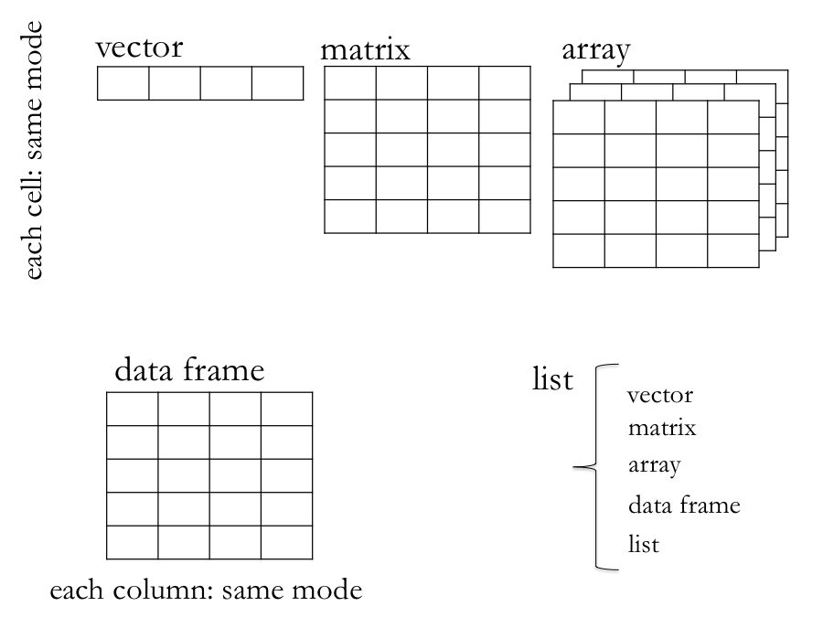

Notice the coercion

```r
x <- c(1,2,3)
x
```

```
## [1] 1 2 3
```

```r
y <- c(1,2,"3")
y
```

```
## [1] "1" "2" "3"
```

```r
mode(y)
```

```
## [1] "character"
```

## Vectorized calculations

- Functions work on the whole structure
- Try not to use loops.

```r
x <- rep(1:3,2)
x
```

```
## [1] 1 2 3 1 2 3
```

```r
x+4
```

```
## [1] 5 6 7 5 6 7
```

```r
sum(x^2)
```

```
## [1] 28
```

```r
y <- matrix(1:9, ncol = 3)
y
```

```
##      [,1] [,2] [,3]
## [1,]    1    4    7
## [2,]    2    5    8
## [3,]    3    6    9
```

```r
# elementwise operation
y/y
```

```
##      [,1] [,2] [,3]
## [1,]    1    1    1
## [2,]    1    1    1
## [3,]    1    1    1
```

Quiz: `y/c(1,2,3) =?`

## Do it yourself

```r
x <- 1:3
y <- c(TRUE, FALSE, TRUE)
z <- c("A","B", "C")
```

What values are returned for the following commands?

```r
x+y
x*y
c(x,z)
c(y,z)
```

## Reproducible reports using `R`

- Is that how you prepare data analysis report?

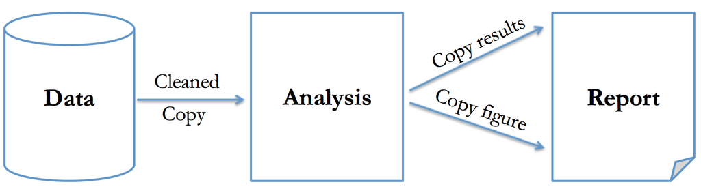

- What if we have to do it again and again
- What if the data changes or part of the data changes
- What if we can do everything from one place

## How can we do this from R?

- Wonderful `R` packages `knitr` and `rmarkdown`

```r
  install.packages("knitr" "rmarkdown")
  library("knitr", "rmarkdown")
```

- Install the packages only once, but you have to include it every time you start `R`
- Its free

## Creating a Markdown (.Rmd) file

- Open a new R Markdown file to start
- The new file will start with a complete template
- Compile (knit) the file from RStudio tool bar
- You can create (knit) it as HTML, word document as well as pdf

[figure not shown]

## Markdown (.Rmd) example

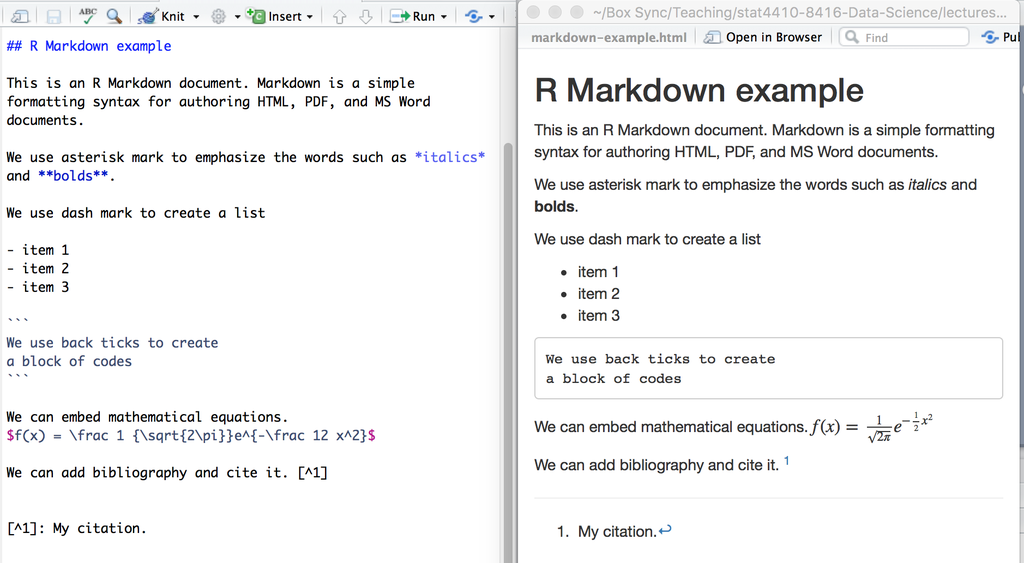

## R code chunk

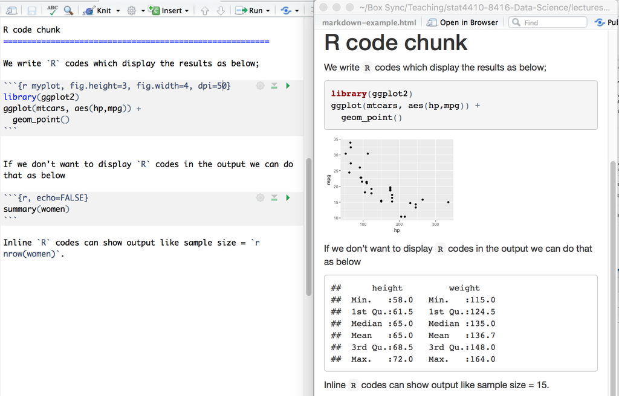

## Showing a table of data

- Use function `kable()` to display a table of data

```r
knitr::kable(head(mtcars, 10))
```

[output not shown]

- Javascript library datatable helps us to generate enhanced table using package `DT`. This feature is available for `HTML` output only.

```r
DT::datatable( head(iris, 12),
  fillContainer = FALSE, options = list(pageLength = 6)
)
```

[output not shown]

## Showing equation

```
$$f(x) = \frac 1{\sqrt{2\pi \sigma^2}}e^{-\frac 1 {2\sigma^2}(x-\mu)^2}$$
```

will produce

\[f(x) = \frac 1{\sqrt{2\pi \sigma^2}}e^{-\frac 1 {2\sigma^2}(x-\mu)^2}\] We use single `$` to write equation inline such as (\(\sigma^2\)) and double `$$` to write equation as above.

## What can you do?

- You may generate periodic reports
  - generate templates, so everyday the same report is updated based on new data
- Share the report online as `HTML` report within your intranet secure network
  - create interactive dashboard to produce customizable report.
  - create a repository of previous data analysis report for other employees to review, use and learn.
- Any other ideas?

## References

- knitr web site  
  http://yihui.name/knitr/
- [knitr book](http://www.amazon.com/dp/1482203537/ref=cm_sw_su_dp), Dynamic Documents with R and knitr by Yihui Xie.
- knitr showcase, examples from other users http://yihui.name/knitr/demo/showcase/